# GWR and MGWR with Space-Time Kernels

Ghislain Geniaux

2025-12-03

# Space-time kernel

One of the earliest extensions to incorporate the temporal dimension into Geographically Weighted Regression (GWR) is the **Geographically and Temporally Weighted Regression (GTWR)**. GTWR enables regression coefficients to vary both spatially and temporally by employing spatiotemporal weights that account for spatial and temporal distances. This approach more effectively captures evolving local dynamics compared to traditional GWR (Huang, B., Wu, B., & Barry, M., 2010). The inclusion of temporal elements enhances the understanding of how relationships change over time, in addition to their spatial variations.

In this package, we have extended the functionality to incorporate **spatiotemporal (separable) kernels** for all available models in the **mgwrsar** package, significantly expanding the range of temporal kernel options. Existing GTWR packages typically offer only symmetric temporal kernels, which do not account for seasonality. However, when working with spatiotemporal data, it is often more appropriate to use **asymmetric spatiotemporal kernels** for the temporal dimension. The asymmetric aspect is particularly crucial in predictive frameworks, as it ensures that only past observations are considered in local samples. Additionally, unlike purely spatial models, certain spatiotemporal processes may involve **cyclic temporal proximities** (Du et al., 2018; Senanayake, O’Callaghan, & Ramos, 2016).

# Multiplicative Separable Kernel

Here, we consider a **multiplicative separable kernel** composed of two components:

- $K_s(d_s, h_s)$ for space, where $d_s$ represents the spatial distance and $h_s$ the spatial bandwidth.
- $K_t(d_t, h_t, cycling, \theta)$ for time, where $d_t$ represents the temporal distance, $h_t$ the temporal bandwidth, $cycling$ defines the seasonal cycle, and $theta$ modulates the weights between seasons.

The space-time kernel is then computed as:
$$K(h_s, h_t, \alpha, cycling, \theta) =
\alpha * (K_s(d_s, h_s) * K_t(d_t, h_t, cycling, \theta)) + (1 - \alpha)
* I_{t_i < t_j}$$

## Kernel Naming Convention

The name of the temporal kernel consists of two to three terms separated by underscores:

1. The first term specifies the kernel type (e.g., `gauss`, `bisq`, `rectangle`, `triangle`, `epane`).
2. The second term can be `past` for an asymmetric kernel or `symmetric` for a kernel that includes all observations.
3. The optional third term defines the cycling/seasonal weight in temporal units (e.g., `gauss_past_365`).

# Implementation in mgwrsar

In the **mgwrsar** package, to use a spatiotemporal kernel, you must provide a complete parameterization for both the spatial and temporal kernels, including the kernel names, whether they are adaptive, and their corresponding bandwidth values.

- For **non-adaptive kernels**, bandwidths are expressed in units of distance and time, respectively.
- For **adaptive kernels**, bandwidths correspond to the number of neighbors.

A spatiotemporal kernel can be specified using the control parameter `type=GDT`. For example:

```
kernels = c('gauss', 'gauss_past_365'),
H = c(20000, 30),
control = list(type = 'GDT', adaptive = c(FALSE, FALSE), alpha = 0.85)
```

The following graph illustrates this kernel with two different parameterizations. The spatial dimension is constrained to a single axis (longitude) to facilitate a 2D representation. The grey areas represent null weights.

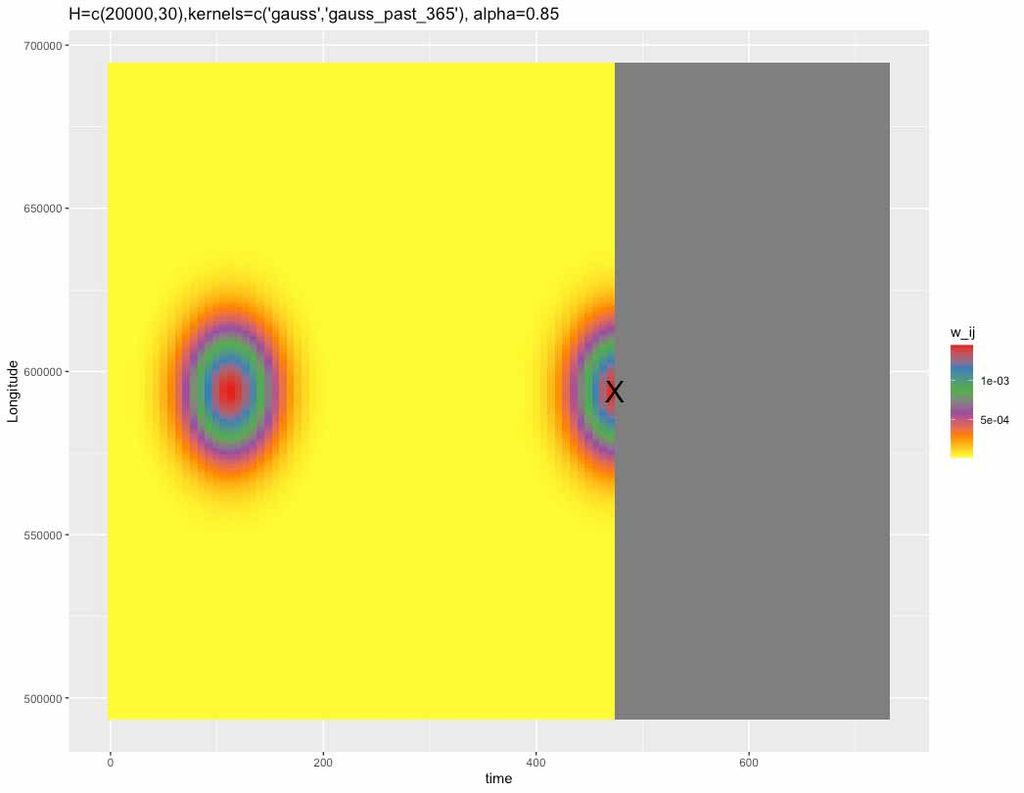

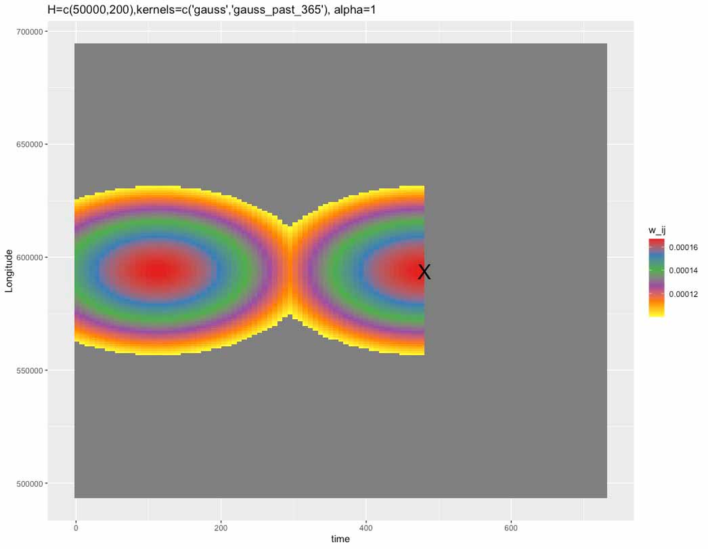

GDT kernel 2

## Simulated GWR with spatiotemporal patterns (Beta1 and Beta2 depend on time)

```r
### Simulation of a spatiotemporal DGP
simu2=simu_multiscale(n=1000,myseed=1,type='GG2024',constant=NULL,nuls=NULL,config_beta='spatiotemp_old',config_snr=0.9,config_eps='normal')
mydata=simu2$mydata
head(mydata)
```

```
#>             Y         X1         X2         X3     Beta1      Beta2      Beta3
#> 1 -11.4384421 -0.4031171  1.2111483  2.4468419 2.4436596 4.57199392 -1.9634418
#> 2  -0.2562656 -0.3666244 -1.0765614  1.1209507 0.7559192 2.73299604  1.6169655
#> 3   2.2700073 -1.4914491  1.0018353  0.7203307 4.7096993 0.08047582 -1.6003074
#> 4   4.0903073 -1.4257676  0.5671312  1.1811011 2.2934309 0.42638579  3.4746349
#> 5  -0.2507761 -1.4019835 -0.9734733 -0.9361378 2.3168024 2.17967726 -1.3891309
#> 6   1.3486069 -0.9617131  0.9088652 -0.3516505 0.1123218 0.49848871  0.6533924
#>       Beta4         eps         x         y Intercept        time
#> 1 -3.316056 -1.54716846 0.6775328 0.4703537         1 0.000000000
#> 2  2.801332 -1.40959374 0.4273457 0.1575829         1 0.001001001
#> 3  2.273613 -2.35417479 0.9103805 0.9881523         1 0.002002002
#> 4 -0.557742  1.09297908 0.9557282 0.1386540         1 0.003003003
#> 5 -1.141711 -1.93278764 0.8406586 0.2603317         1 0.004004004
#> 6 -3.286022 -0.03368842 0.3436612 0.0268338         1 0.005005005
```

```r
coords=simu2$coords
head(coords)
```

```
#>              x         y
#> [1,] 0.6775328 0.4703537
#> [2,] 0.4273457 0.1575829
#> [3,] 0.9103805 0.9881523
#> [4,] 0.9557282 0.1386540
#> [5,] 0.8406586 0.2603317
#> [6,] 0.3436612 0.0268338
```

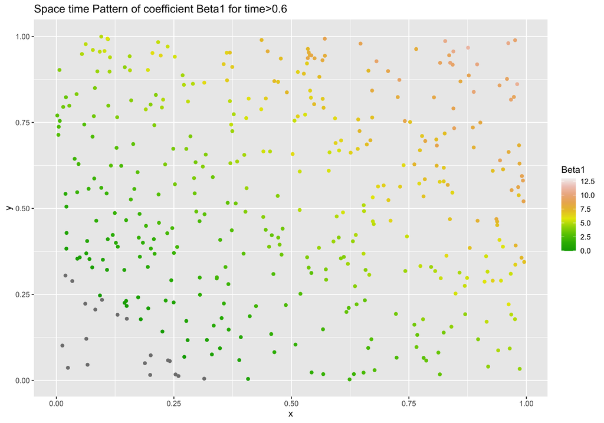

```r
myformula=as.formula('Y~X1+X2+X3')
# storage of coefficients from the data generating process
TRUEBETA<-as.matrix(mydata[,c('Beta1','Beta2','Beta3','Beta4')],ncol=4)

ggplot(mydata[mydata$time>0.6,],aes(x,y))+geom_point(aes(color=Beta1))+ ggtitle('Space time Pattern of coefficient Beta1 for time>0.6')+scale_colour_gradientn(colours = terrain.colors(10),limits=c(0,13))
```

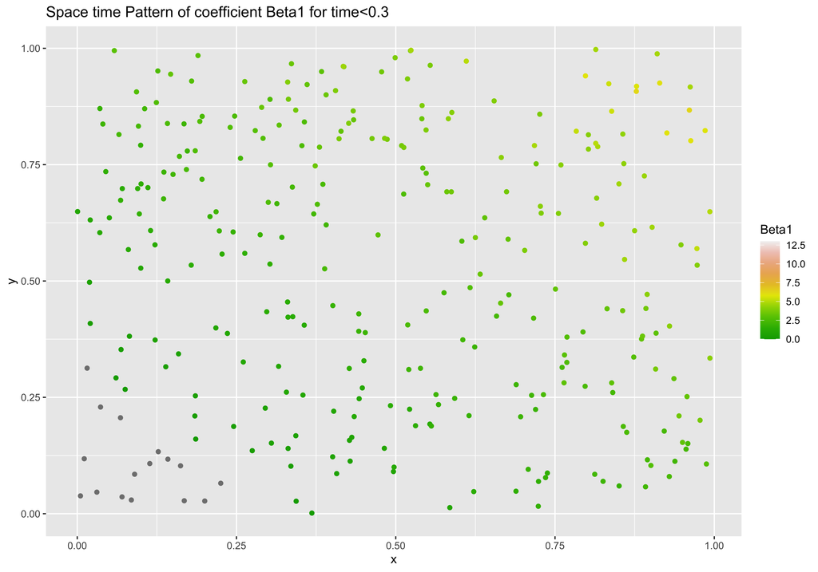

```r
ggplot(mydata[mydata$time<0.3,],aes(x,y))+geom_point(aes(color=Beta1))+ ggtitle('Space time Pattern of coefficient Beta1 for time<0.3')+scale_colour_gradientn(colours = terrain.colors(10),limits=c(0,13))
```

## Spatial and temporal bandwidths optimization

The `golden_search_bandwidth` function is employed to determine the optimal spatial bandwidth $h_s$ for a given temporal bandwidth $h_t$. This process should be iterated across various values of $h_t$ to identify the best pair of bandwidths.

**Note:** In the function parameterizations, $h_t$ corresponds to $H_2$, while $h_s$ corresponds to $H$.

For **estimation and bandwidth search**, it is essential to provide the in-sample time vector through the `control` argument. Here is an example:

```
    control = list(..., Z = mydata$time[index_in], ...)
```

```r
##### Comparing GWR estimation using spatial kernel (type='GD') and  spatiotemproal kernel Type='GDT'

verbose=F
# function to compute rmse from a vector of residuals
rmse<-function(x) sqrt(mean(x^2))

### GWR with spatial non-adaptive Gaussian kernel
res_gwr_GD=golden_search_bandwidth(formula=myformula,Ht=NULL,data = mydata,coords=coords, fixed_vars=NULL,kernels=c('gauss'), Model = 'GWR',control=list(adaptive=F,verbose=verbose,criterion='AICc',doMC=F,ncore=1),lower.bound=0, upper.bound=1.4,tolerance=0.001)
```

```
#>   |                                                                              |                                                                      |   0%  |                                                                              |=                                                        …
```

```r
model_GWR_GD<-res_gwr_GD$model
model_GWR_GD@H
```

```
#> [1] 0.05351798
```

```r
model_GWR_GD@AICc
```

```
#> [1] 5530.986
```

```r
Beta_RMSE=apply((model_GWR_GD@Betav-TRUEBETA) %>% as.data.frame(),2,rmse)
Beta_RMSE
```

```
#> Intercept        X1        X2        X3
#>  1.132364  1.336934  1.183762  1.698138
```

```r
Beta_RMSE%>% mean()
```

```
#> [1] 1.337799
```

```r
### GWR model with a spatio-temporal non-adaptive kernel

# Repeating the following estimation (optimization of the spatial bandwidth)
# with various temporal bandwidth (Ht)
# lead to an optimal value for Ht equal 0.55 regarding AICc criteria

# here is the procedure for Ht = 0.55
# you need to provide the insample time vectorthrough the control argument} : control=list(...,Z=mydata$time)
res_gwr_GDT=golden_search_bandwidth(myformula,Ht=0.55,data = mydata,coords=coords, fixed_vars=NULL,kernels=c('gauss','gauss'),Model = 'GWR',control=list(doMC=F,ncore=1,Z=mydata$time,SE=F,Type='GDT',adaptive=c(F,F),criterion='AICc',get_ts=TRUE,verbose=verbose,NN=nrow(mydata)),lower.bound=0, upper.bound=1.4)
```

```
#>   |                                                                              |                                                                      |   0%  |                                                                              |=                                                        …
```

```r
# results
model_GWR_GDT<-res_gwr_GDT$model
model_GWR_GDT@H
```

```
#> [1] 0.05606901
```

```r
model_GWR_GDT@Ht
```

```
#> [1] 0.55
```

```r
model_GWR_GDT@AICc
```

```
#> [1] 5487.227
```

```r
Beta_RMSE=apply((model_GWR_GDT@Betav-TRUEBETA) %>% as.data.frame(),2,rmse)
Beta_RMSE
```

```
#> Intercept        X1        X2        X3
#> 0.9249335 1.1540686 1.1993543 1.7630121
```

```r
Beta_RMSE%>% mean()
```

```
#> [1] 1.260342
```

## Comparison of GWR Out-of-Sample Predictions for Spatiotemporal DGP

In this analysis, we compare **Geographically Weighted Regression (GWR)** out-of-sample predictions for a spatiotemporal Data Generating Process (DGP) with a larger sample size using two approaches:

1. A **spatial kernel**
2. A **spatiotemporal kernel**

For **out-of-sample prediction**, ensure the following:

1. Provide the in-sample time vector through the `control` argument:

   control = list(…, Z = mydata$time[index_in], …)
2. Provide a matrix with three columns for the new data (longitude, latitude, time):

   new_data=matrix(cbind(coords[index_out,], mydata$time[index_out]), ncol = 3)

```r
## simulations
simu3=simu_multiscale(n=2000,myseed=1,type='GG2024',constant=NULL,
                      nuls=NULL,config_beta='spatiotemp_old',config_snr=0.9,
                      config_eps='normal')

mydata=simu3$mydata
head("mydata")
```

```
#> [1] "mydata"
```

```r
coords=simu3$coords
head("coords")
```

```
#> [1] "coords"
```

```r
myformula=as.formula('Y~X1+X2+X3')

# betas from the DGP
TRUEBETA<-as.matrix(mydata[,c('Beta1','Beta2','Beta3','Beta4')],ncol=4)

# build in sample and ousample folds
index_in=which(mydata$time<0.7)
index_out=(1:2000)[-index_in]

### model estimation, insample estimates comparison
## Comparing GWR estimation using spatial kernel (type='GD') and  spatiotemproal kernel Type='GDT'
# (same as in the previous part, comparison of insample beta estimates)

verbose=F

## GWR model with a Gaussian non-adaptive kernel
# model estimation
res_gwr_GD2=golden_search_bandwidth(formula=myformula,Ht=NULL,data = mydata[index_in,],coords=coords[index_in,], fixed_vars=NULL,kernels=c('gauss'), Model = 'GWR',control=list(adaptive=F,verbose=verbose,criterion='AICc',doMC=F,ncore=1),lower.bound=0, upper.bound=1.4,tolerance=0.001)
```

```
#>   |                                                                              |                                                                      |   0%  |                                                                              |=                                                        …
```

```r
#results
model_GWR_GD<-res_gwr_GD2$model
model_GWR_GD@H
```

```
#> [1] 0.04482225
```

```r
model_GWR_GD@AICc
```

```
#> [1] 7393.582
```

```r
Beta_RMSE=apply((model_GWR_GD@Betav-TRUEBETA[index_in,]) %>% as.data.frame(),2,rmse)
# rmse for insample beta estimates with GWR-GD
Beta_RMSE
```

```
#> Intercept        X1        X2        X3
#> 0.9139482 1.0639860 1.0266448 1.2099487
```

```r
Beta_RMSE%>% mean()
```

```
#> [1] 1.053632
```

```r
## Repeating the following estimation with various Ht lead to an optimal value for Ht equal 0.45 regarding AICc criteria

res_gwr_GDT2=golden_search_bandwidth(myformula,Ht=0.45,data = mydata[index_in,],coords=coords[index_in,], fixed_vars=NULL,kernels=c('gauss','gauss'),Model = 'GWR',control=list(doMC=F,ncore=1,Z=mydata$time[index_in],SE=F,Type='GDT',adaptive=c(F,F),criterion='AICc',get_ts=TRUE,verbose=verbose),lower.bound=0, upper.bound=1.4)
```

```
#>   |                                                                              |                                                                      |   0%  |                                                                              |=                                                        …
```

```r
model_GWR_GDT<-res_gwr_GDT2$model
model_GWR_GDT@H
```

```
#> [1] 0.04700794
```

```r
model_GWR_GDT@Ht
```

```
#> [1] 0.45
```

```r
model_GWR_GDT@AICc
```

```
#> [1] 7381.698
```

```r
Beta_RMSE=apply((model_GWR_GDT@Betav-TRUEBETA[index_in,]) %>% as.data.frame(),2,rmse)
# rmse for insample beta estimates with GWR-GDT
Beta_RMSE
```

```
#> Intercept        X1        X2        X3
#> 0.8443158 0.9621489 1.0452153 1.2619089
```

```r
Beta_RMSE%>% mean()
```

```
#> [1] 1.028397
```

```r
#### outsample PREDICTIONS comparison
# outsample data
newdata<-mydata[index_out,]
newdata_coords=coords[index_out,]
# you need to make a matrix with space and time coordinates
newdata_coords_time=matrix(cbind(coords[index_out,],mydata$time[index_out]),ncol=3)

### GWR
Y_pred17=predict(model_GWR_GD, newdata=newdata, newdata_coords=newdata_coords,method_pred='model')
head(Y_pred17)
```

```
#> [1]  3.955152  2.486668 -3.089725 -1.850668  7.306520 15.066287
```

```r
head(mydata$Y[index_out])
```

```
#> [1]  4.7387924  0.1311622 -7.5043022  1.7939808 15.4717344 22.6727852
```

```r
# RMSE for outsample predictions (GWR)
sqrt(mean((mydata$Y[index_out]-Y_pred17)^2))
```

```
#> [1] 4.266011
```

```r
### GWR GDT
Y_pred18=predict(model_GWR_GDT, newdata=newdata, newdata_coords=newdata_coords_time,method_pred='model')
head(Y_pred18)
```

```
#> [1]  4.592953  2.054565 -3.103452 -2.229137  7.894201 15.663021
```

```r
head(mydata$Y[index_out])
```

```
#> [1]  4.7387924  0.1311622 -7.5043022  1.7939808 15.4717344 22.6727852
```

```r
# RMSE for outsample predictions (GWR GDT), method_pred='tWtp_model'
sqrt(mean((mydata$Y[index_out]-Y_pred18)^2))
```

```
#> [1] 4.002258
```

```r
Y_pred19=predict(model_GWR_GDT, newdata=newdata, newdata_coords=newdata_coords_time,method_pred='model')
head(Y_pred19)
```

```
#> [1]  4.592953  2.054565 -3.103452 -2.229137  7.894201 15.663021
```

```r
head(mydata$Y[index_out])
```

```
#> [1]  4.7387924  0.1311622 -7.5043022  1.7939808 15.4717344 22.6727852
```

```r
# RMSE for outsample predictions (GWR GDT), method_pred='tWtp_model'
sqrt(mean((mydata$Y[index_out]-Y_pred19)^2))
```

```
#> [1] 4.002258
```

# References:

Huang, B., Wu, B., & Barry, M. (2010). Geographically and temporally weighted regression for modeling spatio-temporal variation in house prices. International journal of geographical information science, 24(3), 383-401.

Du et al., 2018, “Extending geographically and temporally weighted regression to account for both spatiotemporal heterogeneity and seasonal variations in coastal seas,” Ecological Informatics, 43, 185-199;

Senanayake, O’Callaghan, & Ramos, 2016, “Predicting spatiotemporal propagation of seasonal influenza using variational Gaussian process regression,” Proceedings of the AAAI Conference on Artificial Intelligence, Vol. 30, No. 1